# PA1_template.Rmd

Reem Soliman

January 14, 2017

# Reproducible Research Course - Project 1

It is now possible to collect a large amount of data about personal movement using activity monitoring devices such as a Fitbit, Nike Fuelband, or Jawbone Up. These type of devices are part of the “quantified self” movement - a group of enthusiasts who take measurements about themselves regularly to improve their health, to find patterns in their behavior, or because they are tech geeks. But these data remain under-utilized both because the raw data are hard to obtain and there is a lack of statistical methods and software for processing and interpreting the data.

This assignment makes use of data from a personal activity monitoring device. This device collects data at 5 minute intervals through out the day. The data consists of two months of data from an anonymous individual collected during the months of October and November, 2012 and include the number of steps taken in 5 minute intervals each day.

1- Code for reading in the dataset and/or processing the data

```r
knitr::opts_chunk$set(fig.width=12, fig.height=8, fig.path='Figs/', warning=FALSE, message=FALSE)
library(plyr)
library(ggplot2)
library(dplyr)
setwd("C://DataScienceProgram//Reproducible//week2")
activity <- read.csv("activity1.csv")
colnames(activity)[2] <- c("ActivityDate")
summary(activity)
```

```
##      steps            ActivityDate      interval
##  Min.   :  0.00   2012-10-01:  288   Min.   :   0.0
##  1st Qu.:  0.00   2012-10-02:  288   1st Qu.: 588.8
##  Median :  0.00   2012-10-03:  288   Median :1177.5
##  Mean   : 37.38   2012-10-04:  288   Mean   :1177.5
##  3rd Qu.: 12.00   2012-10-05:  288   3rd Qu.:1766.2
##  Max.   :806.00   2012-10-06:  288   Max.   :2355.0
##  NA's   :2304     (Other)   :15840
```

2- Histogram of the total number of steps taken each day

```r
count <- aggregate(steps ~ ActivityDate, activity, FUN = "sum")
summary(count)
```

```
##      ActivityDate     steps
##  2012-10-02: 1    Min.   :   41
##  2012-10-03: 1    1st Qu.: 8841
##  2012-10-04: 1    Median :10765
##  2012-10-05: 1    Mean   :10766
##  2012-10-06: 1    3rd Qu.:13294
##  2012-10-07: 1    Max.   :21194
##  (Other)   :47
```

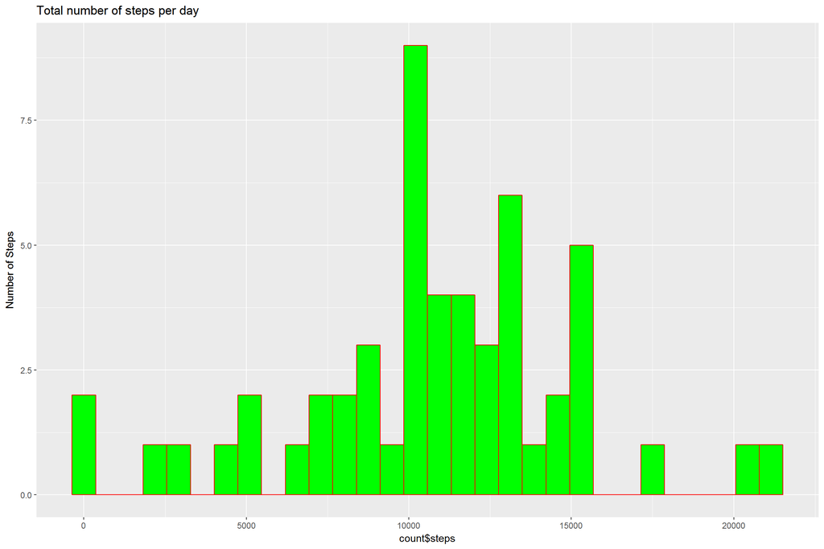

```r
g<- ggplot(data= count, aes( count$steps) ) + geom_histogram(col="red", fill="green") + labs(title = "Total number of steps per day")+labs(y="Number of Steps")
print(g)
```

3-Mean and median number of steps taken each day

```r
StepsMean <- aggregate(steps ~ ActivityDate, activity, FUN = "mean")
StepsMedian <- aggregate(steps ~ ActivityDate, activity, FUN = "median")
n<- join(StepsMean, StepsMedian, by = "ActivityDate" )
colnames(n)[2]<- c("Mean")
colnames(n)[3]<- c("Median")
print(n)
```

```
##    ActivityDate       Mean Median
## 1    2012-10-02  0.4375000      0
## 2    2012-10-03 39.4166667      0
## 3    2012-10-04 42.0694444      0
## 4    2012-10-05 46.1597222      0
## 5    2012-10-06 53.5416667      0
## 6    2012-10-07 38.2465278      0
## 7    2012-10-09 44.4826389      0
## 8    2012-10-10 34.3750000      0
## 9    2012-10-11 35.7777778      0
## 10   2012-10-12 60.3541667      0
## 11   2012-10-13 43.1458333      0
## 12   2012-10-14 52.4236111      0
## 13   2012-10-15 35.2048611      0
## 14   2012-10-16 52.3750000      0
```

[output cut: 39 more lines]

4-Time series plot of the average number of steps taken

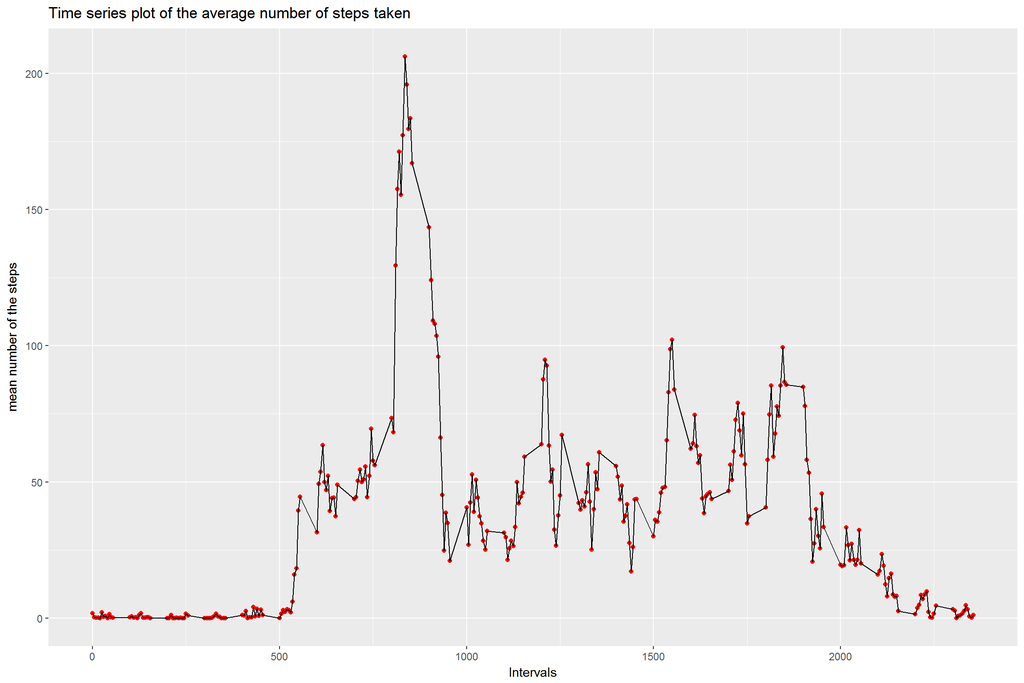

```r
StepsMeanOverTimeIntervals<- aggregate(steps ~ interval, activity, FUN = "mean")
g<- ggplot(data= StepsMeanOverTimeIntervals, aes(interval, steps) )+ geom_point(col="red")+ labs(title = "Time series plot of the average number of steps taken")+labs(x="Intervals", y="mean number of the steps") +geom_line()
print(g)
```

5-The 5-minute interval that, on average, contains the maximum number of steps

```r
m <- max(StepsMeanOverTimeIntervals[2], na.rm = TRUE)
n <- which.max(as.double(StepsMeanOverTimeIntervals[[2]]))
h<- StepsMeanOverTimeIntervals[[n,1]]
print(h)
```

```
## [1] 835
```

Interval 835 has the maximum average number of steps

6- Code to describe and show a strategy for imputing missing data

```r
#copy the data in another dataframe
activityCpy <- activity
#get the rows with NA
n <- which(is.na(activityCpy))
for (i in 1:length(n)) {
  index <- n[i]
  intervalOfNA <- activityCpy[index,3]

  MeanOfTheInterval <- StepsMeanOverTimeIntervals[which(StepsMeanOverTimeIntervals[,1] ==    intervalOfNA),2]
  #replace the NA in steps with the mean for that 5-minute interval
  activityCpy[index,1] <- MeanOfTheInterval
}
summary(activityCpy)
```

```
##      steps            ActivityDate      interval
##  Min.   :  0.00   2012-10-01:  288   Min.   :   0.0
##  1st Qu.:  0.00   2012-10-02:  288   1st Qu.: 588.8
##  Median :  0.00   2012-10-03:  288   Median :1177.5
##  Mean   : 37.38   2012-10-04:  288   Mean   :1177.5
##  3rd Qu.: 27.00   2012-10-05:  288   3rd Qu.:1766.2
##  Max.   :806.00   2012-10-06:  288   Max.   :2355.0
##                   (Other)   :15840
```

Notice that there is no NAs in the dataset copy now!

7-Histogram of the total number of steps taken each day after missing values are imputed

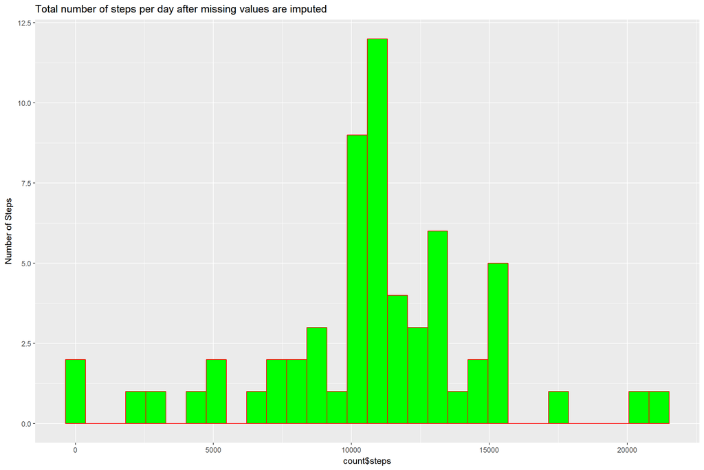

```r
count <- aggregate(steps ~ ActivityDate, activityCpy, FUN = "sum")
g<- ggplot(data= count, aes( count$steps) ) + geom_histogram(col="red", fill="green") + labs(title = "Total number of steps per day after missing values are imputed")+labs(y="Number of Steps")
print(g)
```

8- Panel plot comparing the average number of steps taken per 5-minute interval across weekdays and weekends

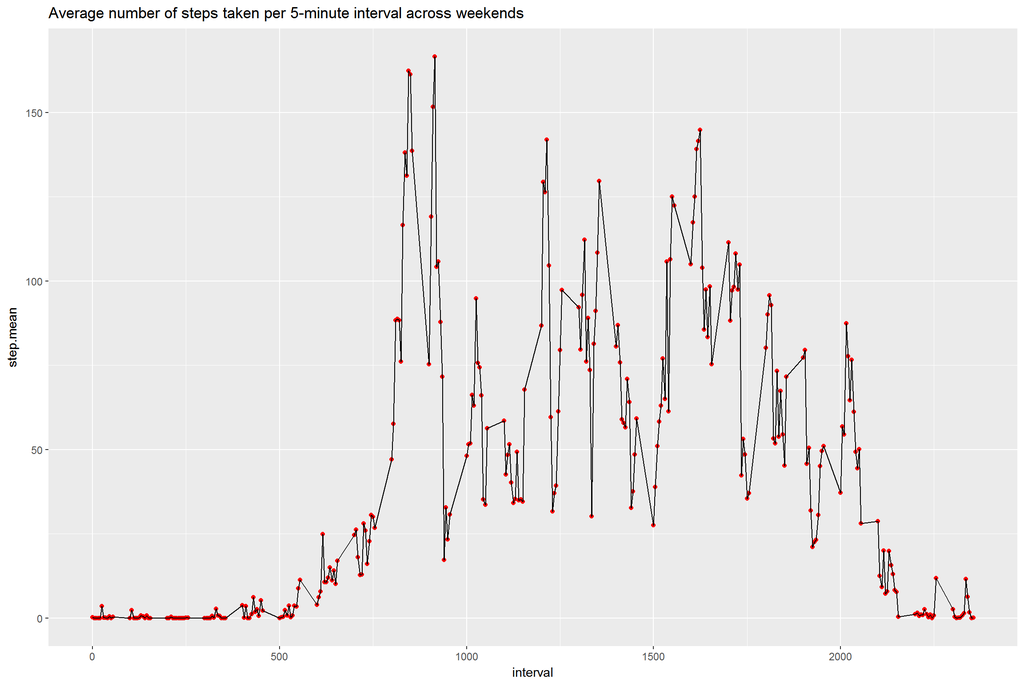

```r
activityCpy$ActivityDate <- as.Date(activityCpy$ActivityDate)
weekdays1 <- c('Monday', 'Tuesday', 'Wednesday', 'Thursday', 'Friday')
activityCpy$wDay <- factor((weekdays(activityCpy$ActivityDate) %in% weekdays1), levels=c(FALSE, TRUE), labels=c('weekend','weekday') )
#subset and group by interval
weekends <- activityCpy %>% filter(wDay=="weekend") %>% group_by(interval) %>%summarise(step.mean = mean(steps))
weekdays <- activityCpy %>% filter(wDay=="weekday") %>% group_by(interval) %>%summarise(step.mean = mean(steps))

weekendsPlot<- ggplot(data= weekends, aes(interval, step.mean) )+ geom_point(col="red")+geom_line()+labs(title = "Average number of steps taken per 5-minute interval across weekends")
print(weekendsPlot)
```

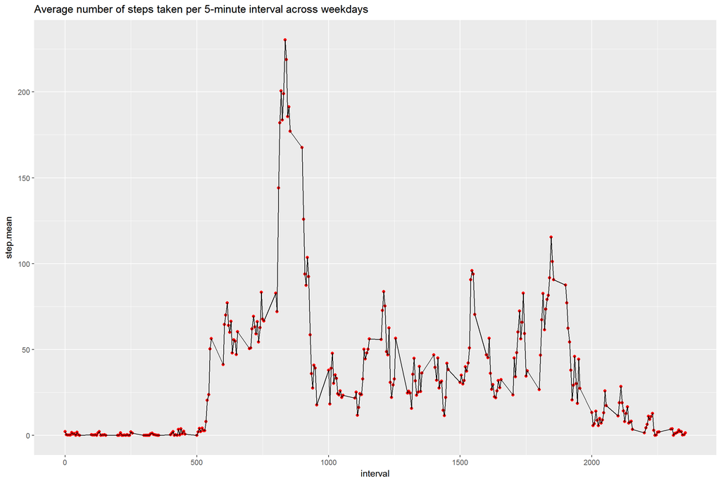

```r
weekdaysPlot<- ggplot(data= weekdays, aes(interval, step.mean) )+ geom_point(col="red")+geom_line()+labs(title = "Average number of steps taken per 5-minute interval across weekdays")
print(weekdaysPlot)
```